### Unit 3: Penguins

```r
library(tidyverse)
library(palmerpenguins)
```

### Exercise 1.1

Build a data set that contains only Chinstrap penguins. Then build another data set that contains only Chinstrap penguins with a flipper length > 200 mm. What is the sex ratio of Chinstrap penguins? How does that compare to the sex ratio of Chinstrap penguins with a flipper length > 200 mm? Use the `summary()` function to examine sex ratios. Given this analysis, what do you think the relationship is between sex and flipper length?

```r
# Sex ratio of all Chinstrap observations
chin = penguins %>% filter(species=="Chinstrap")
summary(chin)
```

```
##       species         island   bill_length_mm  bill_depth_mm
##  Adelie   : 0   Biscoe   : 0   Min.   :40.90   Min.   :16.40
##  Chinstrap:68   Dream    :68   1st Qu.:46.35   1st Qu.:17.50
##  Gentoo   : 0   Torgersen: 0   Median :49.55   Median :18.45
##                                Mean   :48.83   Mean   :18.42
##                                3rd Qu.:51.08   3rd Qu.:19.40
##                                Max.   :58.00   Max.   :20.80
##  flipper_length_mm  body_mass_g       sex          year
##  Min.   :178.0     Min.   :2700   female:34   Min.   :2007
##  1st Qu.:191.0     1st Qu.:3488   male  :34   1st Qu.:2007
##  Median :196.0     Median :3700               Median :2008
##  Mean   :195.8     Mean   :3733               Mean   :2008
##  3rd Qu.:201.0     3rd Qu.:3950               3rd Qu.:2009
##  Max.   :212.0     Max.   :4800               Max.   :2009
```

```r
sex_ratio_all = 34/68

# Sex ratio of Chinstrap penguins with flipper length > 200 mm
chin_long_wing_ladies = penguins %>%
  filter(species == "Chinstrap",
         flipper_length_mm > 200)
summary(chin_long_wing_ladies)
```

```
##       species         island   bill_length_mm  bill_depth_mm
##  Adelie   : 0   Biscoe   : 0   Min.   :43.50   Min.   :18.10
##  Chinstrap:18   Dream    :18   1st Qu.:50.27   1st Qu.:18.85
##  Gentoo   : 0   Torgersen: 0   Median :50.90   Median :19.55
##                                Mean   :51.02   Mean   :19.41
##                                3rd Qu.:52.00   3rd Qu.:19.88
##                                Max.   :55.80   Max.   :20.80
##  flipper_length_mm  body_mass_g       sex          year
##  Min.   :201.0     Min.   :3400   female: 1   Min.   :2007
##  1st Qu.:201.2     1st Qu.:3962   male  :17   1st Qu.:2008
##  Median :203.0     Median :4050               Median :2009
##  Mean   :204.6     Mean   :4131               Mean   :2008
##  3rd Qu.:206.8     3rd Qu.:4300               3rd Qu.:2009
##  Max.   :212.0     Max.   :4800               Max.   :2009
```

```r
sex_ratio_subset = 1/18
```

### Exercise 1.2

Repeat Exercise 1.1, but this time use `group_by()` along with the `n()` function inside `summarize()` to count the number of Chinstrap penguins of each sex. Again compare the sex ratio of all Chinstrap observations vs. the sex ratio of Chinstrap penguins with a flipper length > 200 mm.

```r
penguins %>%
  filter(species == "Chinstrap") %>%
  group_by(sex) %>%
  summarize(n=n())
## `summarise()` ungrouping output (override with `.groups` argument)
## # A tibble: 2 x 2
##   sex        n
##   <fct>  <int>
## 1 female    34
## 2 male      34


penguins %>%
  filter(species == "Chinstrap",
         flipper_length_mm > 200) %>%
  group_by(sex) %>%
  summarize(n=n())
## `summarise()` ungrouping output (override with `.groups` argument)
## # A tibble: 2 x 2
##   sex        n
##   <fct>  <int>
## 1 female     1
## 2 male      17
```

### Exercise 1.3

What is the mean bill length (in inches) of Adelie penguins found on either Dream island or Biscoe island? What is the standard deviation? Is the mean larger or smaller than the mean bill length of Adelie penguins found on Torgersen island?

```r
penguins %>%
  filter(species=="Adelie",
         island %in% c("Biscoe","Dream")) %>%
  mutate(bill_length_in = bill_length_mm * 0.039) %>% # Conversion: 0.0393701 inches / mm
  summarize(mean_bill_length_in = mean(bill_length_in),
            sd_bill_length_in = sd(bill_length_in))
```

```
## # A tibble: 1 x 2
##   mean_bill_length_in sd_bill_length_in
##                 <dbl>             <dbl>
## 1                1.51            0.0964
```

```r
penguins %>%
  filter(species=="Adelie",
         island =="Torgersen",
         !is.na(bill_length_mm)) %>%
  mutate(bill_length_in = bill_length_mm * 0.039) %>% # Conversion: 0.0393701 inches / mm
  summarize(mean_bill_length_in = mean(bill_length_in),
            sd_bill_length_in = sd(bill_length_in))
```

```
## # A tibble: 1 x 2
##   mean_bill_length_in sd_bill_length_in
##                 <dbl>             <dbl>
## 1                1.52             0.118
```

### Exercise 2.1

Build a scatter plot of bill depth vs. bill length for Adelie penguins. Map the point colors to the island that the Adelie penguin was observed on. Add axes labels and a main title.

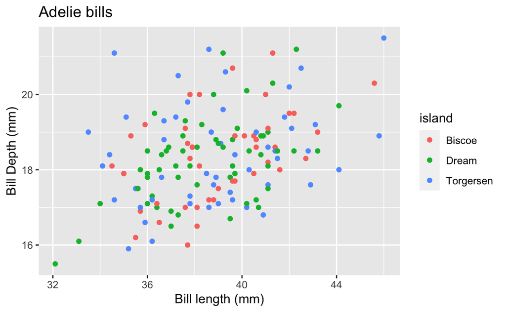

```r
adelie = penguins %>%
  filter(species=="Adelie")
ggplot(data = adelie) +
  geom_point(aes(y=bill_depth_mm, x=bill_length_mm, color=island)) +
  xlab("Bill length (mm)") +
  ylab("Bill Depth (mm)") +
  ggtitle("Adelie bills")
```

### Exercise 2.2

Build another scatter plot of bill depth vs. bill length for all three penguin species. Map the point colors to the penguin’s sex. Use `facet_wrap()` to plot each species in a separate panel. Look at the documentation for `facet_wrap()` and play around with the `scales` parameter. What is the default value? Try plotting with the parameter `scales="free"`. Instead of using the default theme, choose a different pre-packaged theme (I like `theme_bw()` and `theme_classic()`). Save the plot.

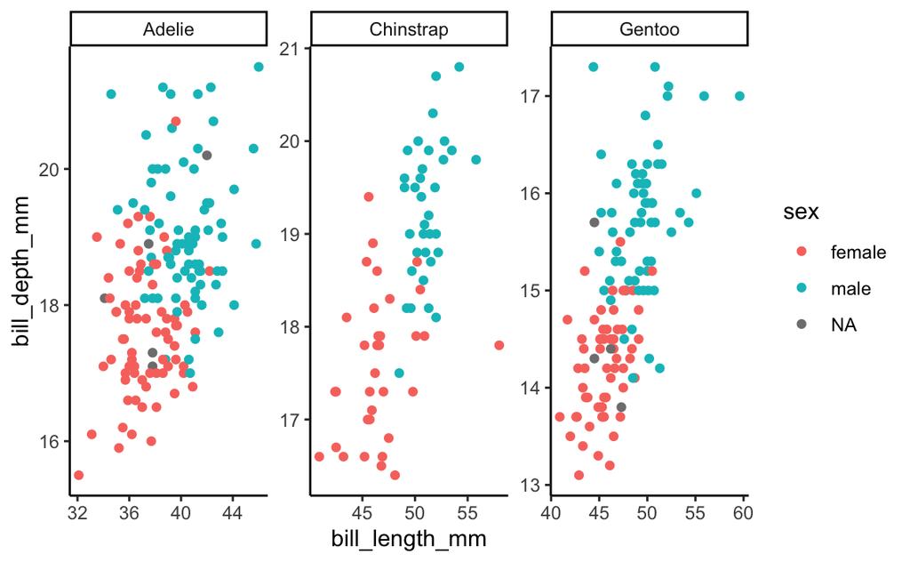

```r
ggplot(data = penguins) +
  geom_point(aes(y=bill_depth_mm, x=bill_length_mm, color=sex)) +
  facet_wrap(~species, scales="free") +
  theme_classic() +
  ggsave(filename = "figures/bill_depth_v_length.png", device = "png", width = 6, height = 3.5, units = "in", dpi = 300)
## Warning: Removed 2 rows containing missing values (geom_point).
```

### Exercise 3.1

Are Adelie penguin flipper lengths significantly different between males and females? Do some exploratory data analysis. Compute summary statistics and plot histograms. Then conduct an independent sample t-test. What do your results show?

```r
library(rstatix) # t_test()
# Simplify the dataset to what we need
ex_1_data = penguins %>%
  filter(species =="Adelie",
         !is.na(flipper_length_mm),
         !is.na(sex)) %>%   # students may forget to do this
  dplyr::select(sex, flipper_length_mm) %>%
  droplevels() # removes empty levels from factors

summary(ex_1_data)
```

```
##      sex     flipper_length_mm
##  female:73   Min.   :172.0
##  male  :73   1st Qu.:186.0
##              Median :190.0
##              Mean   :190.1
##              3rd Qu.:195.0
##              Max.   :210.0
```

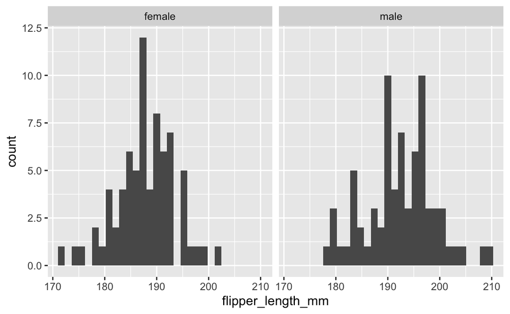

```r
# Calculate summary stats
ex_1_data %>%
  group_by(sex) %>%
  summarize(mean=mean(flipper_length_mm), sd=sd(flipper_length_mm))
## `summarise()` ungrouping output (override with `.groups` argument)
## # A tibble: 2 x 3
##   sex     mean    sd
##   <fct>  <dbl> <dbl>
## 1 female  188.  5.60
## 2 male    192.  6.60

# Plot a quick histogram:
ggplot() +
  geom_histogram(aes(x=flipper_length_mm), data=ex_1_data) +
  facet_wrap(~sex)
## `stat_bin()` using `bins = 30`. Pick better value with `binwidth`.
```

```r
# Base R:
t.test(ex_1_data$flipper_length_mm ~ ex_1_data$sex)
```

```
##
##  Welch Two Sample t-test
##
## data:  ex_1_data$flipper_length_mm by ex_1_data$sex
## t = -4.5589, df = 140.25, p-value = 1.11e-05
## alternative hypothesis: true difference in means is not equal to 0
## 95 percent confidence interval:
##  -6.618429 -2.614448
## sample estimates:
## mean in group female   mean in group male
##             187.7945             192.4110
```

```r
# rstatix:
ex_1_data %>%
  t_test(flipper_length_mm ~ sex)
```

```
## # A tibble: 1 x 8
##   .y.               group1 group2    n1    n2 statistic    df         p
## * <chr>             <chr>  <chr>  <int> <int>     <dbl> <dbl>     <dbl>
## 1 flipper_length_mm female male      73    73     -4.56  140. 0.0000111
```

```r
# Flipper length is significantly different between the 2 sexes
```

### Exercise 4.1

Calculate the correlation between bill length and bill depth with all 3 penguin species combined into a single data set. Is the correlation stronger or weaker compared to the correlation between bill length and bill depth for Gentoo penguins alone? Do you notice anything unexpected about this correlation?

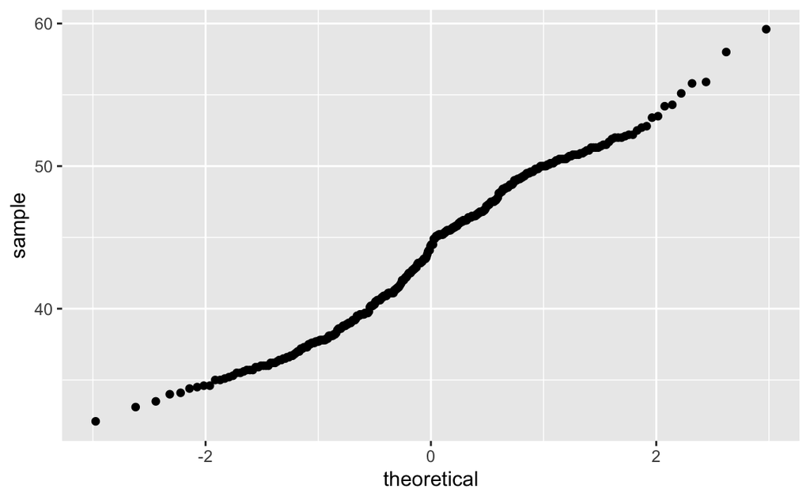

```r
# Check normality assumption with a qqplot:
ggplot(penguins) +
  stat_qq(aes(sample=bill_length_mm))
```

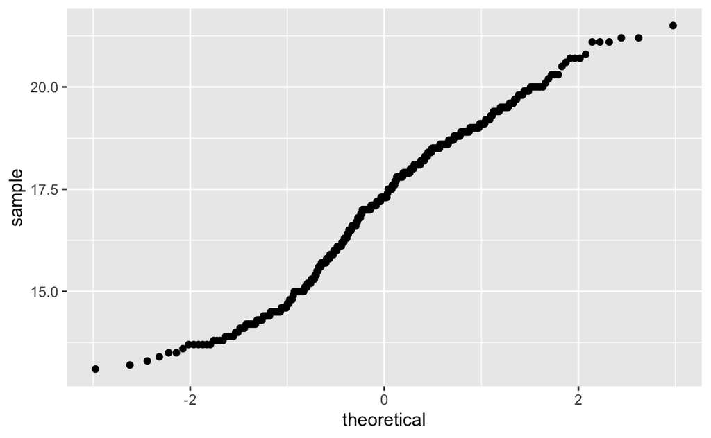

```r
ggplot(penguins) +
  stat_qq(aes(sample=bill_depth_mm))
```

```r
cor.test(x=penguins$bill_length_mm, y=penguins$bill_depth_mm, use="complete.obs")
```

```
##
##  Pearson's product-moment correlation
##
## data:  penguins$bill_length_mm and penguins$bill_depth_mm
## t = -4.4591, df = 340, p-value = 1.12e-05
## alternative hypothesis: true correlation is not equal to 0
## 95 percent confidence interval:
##  -0.3328072 -0.1323004
## sample estimates:
##        cor
## -0.2350529
```

```r
# Correlation is much weaker with all penguins combined than with Gentoo alone
# Correlation with all penguins combined is NEGATIVE - why would bill length get bigger as bill depth gets smaller?
```

[output not shown]

### Exercise 5.1

Build a model predicting Gentoo bill depth as a function of flipper length. Plot the predictions. Which explanatory variable (bill length vs. flipper length) does a better job of predicting bill depth? What is your evidence?

```r
gentoo = penguins %>% filter(species=="Gentoo")

lm_bill_length = lm(bill_depth_mm ~ bill_length_mm, data=gentoo)
summary(lm_bill_length)
```

```
##
## Call:
## lm(formula = bill_depth_mm ~ bill_length_mm, data = gentoo)
##
## Residuals:
##      Min       1Q   Median       3Q      Max
## -1.55952 -0.52572 -0.06658  0.46041  2.95390
##
## Coefficients:
##                Estimate Std. Error t value Pr(>|t|)
## (Intercept)     5.25101    1.05481   4.978 2.15e-06 ***
## bill_length_mm  0.20484    0.02216   9.245 1.02e-15 ***
## ---
## Signif. codes:  0 '***' 0.001 '**' 0.01 '*' 0.05 '.' 0.1 ' ' 1
##
## Residual standard error: 0.7543 on 121 degrees of freedom
##   (1 observation deleted due to missingness)
## Multiple R-squared:  0.4139, Adjusted R-squared:  0.4091
## F-statistic: 85.46 on 1 and 121 DF,  p-value: 1.016e-15
```

```r
lm_flip = lm(bill_depth_mm ~ flipper_length_mm, data=gentoo)
summary(lm_flip)
```

```
##
## Call:
## lm(formula = bill_depth_mm ~ flipper_length_mm, data = gentoo)
##
## Residuals:
##      Min       1Q   Median       3Q      Max
## -1.64831 -0.48630  0.01715  0.39824  2.12406
##
## Coefficients:
##                    Estimate Std. Error t value Pr(>|t|)
## (Intercept)       -8.236854   2.114995  -3.895 0.000162 ***
## flipper_length_mm  0.106908   0.009734  10.983  < 2e-16 ***
## ---
## Signif. codes:  0 '***' 0.001 '**' 0.01 '*' 0.05 '.' 0.1 ' ' 1
##
## Residual standard error: 0.6972 on 121 degrees of freedom
##   (1 observation deleted due to missingness)
## Multiple R-squared:  0.4992, Adjusted R-squared:  0.4951
## F-statistic: 120.6 on 1 and 121 DF,  p-value: < 2.2e-16
```

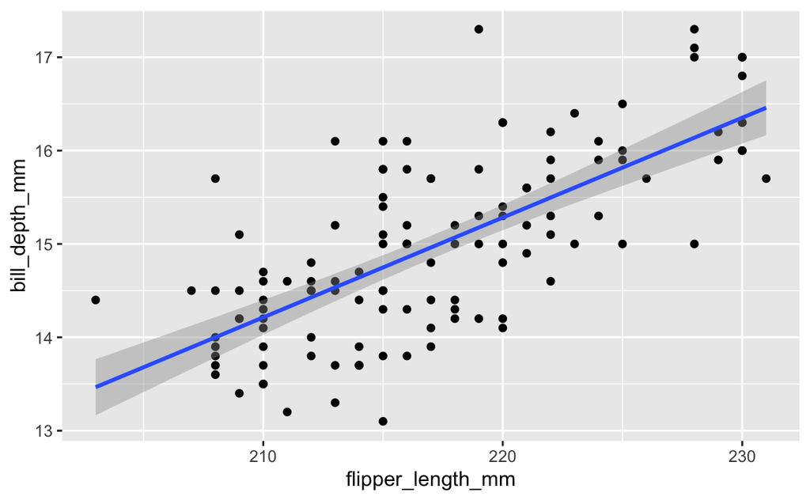

```r
ggplot(data=gentoo, aes(x = flipper_length_mm, y = bill_depth_mm)) +
     geom_point() +
     geom_smooth(method = "lm")
## `geom_smooth()` using formula 'y ~ x'
## Warning: Removed 1 rows containing non-finite values (stat_smooth).
## Warning: Removed 1 rows containing missing values (geom_point).
```

```r
AIC(lm_flip, lm_bill_length)
```

```
##                df      AIC
## lm_flip         3 264.3226
## lm_bill_length  3 283.6673
```

The Adjusted $R^2$ is higher in the flipper model than in the bill length model, so flipper length does a better job of predicting bill depth for Gentoo penguins. You can also compare the Akaike Information Criteria of the two models with `AIC()`, and the model with the smaller AIC is a better fit. Differences of >2 AIC units are considered statistically significant.

### Exercise 5.2

Plot the model predictions from our model `lm_gentoo_3` so that we can see the variation in bill depth vs. flipper length while holding bill length and body mass constant at their medians.

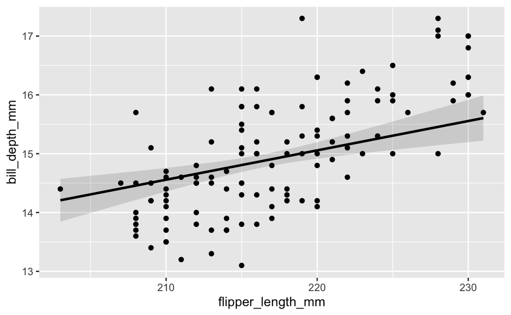

```r
gentoo = penguins %>% filter(species=="Gentoo")
lm_gentoo_3 = lm(bill_depth_mm ~ bill_length_mm + flipper_length_mm + body_mass_g, data=gentoo)

### Look at bill depth ~ flipper length while holding bill length and body mass constant
# Use expand to get full range of 1 variable, then add in median of other variable(s) from original data
newdata = gentoo %>%
  expand(flipper_length_mm) %>% # Full range of data (gets rid of other variables)
  mutate(bill_length_mm = median(gentoo$bill_length_mm, na.rm=TRUE),
         body_mass_g = median(gentoo$body_mass_g, na.rm=TRUE))

lm_gentoo_3_predict = lm_gentoo_3 %>%
  augment(newdat = newdata, se_fit=TRUE) %>%
  mutate(lwr = .fitted - 1.96 * .se.fit, upr = .fitted + 1.96 * .se.fit) # Calculate 95% C.I. using SE
# Plot the data and the model predictions
ggplot() +
  geom_point(aes(x = flipper_length_mm, y = bill_depth_mm), data=gentoo) + # original data
  geom_ribbon(aes(ymin = lwr, ymax = upr, x = flipper_length_mm), alpha = .15, data=lm_gentoo_3_predict) +
  geom_line(data=lm_gentoo_3_predict, aes(y = .fitted, x = flipper_length_mm), size = 1)
```

### Exercise 5.3

Conduct an Analysis of Variance to determine whether Adelie body mass is significantly different between the three islands where observations were collected. Conduct a post-hoc Tukey test if appropriate.

```r
adelie_anova = aov(body_mass_g ~ island + sex, data=penguins %>% filter(species=="Adelie"))
summary(adelie_anova)
```

```
##              Df   Sum Sq  Mean Sq F value Pr(>F)
## island        2     2064     1032   0.011  0.989
## sex           1 16622756 16622756 170.141 <2e-16 ***
## Residuals   142 13873382    97700
## ---
## Signif. codes:  0 '***' 0.001 '**' 0.01 '*' 0.05 '.' 0.1 ' ' 1
## 6 observations deleted due to missingness
```

```r
TukeyHSD(adelie_anova)  # Illogical analysis since ANOVA shows no difference btwn island
```

```
##   Tukey multiple comparisons of means
##     95% family-wise confidence level
##
## Fit: aov(formula = body_mass_g ~ island + sex, data = penguins %>% filter(species == "Adelie"))
##
## $island
##                       diff       lwr      upr     p adj
## Dream-Biscoe     -8.295455 -158.0357 141.4448 0.9905535
## Torgersen-Biscoe -1.148453 -156.4494 154.1525 0.9998309
## Torgersen-Dream   7.147002 -139.9144 154.2084 0.9927221
##
## $sex
##                 diff      lwr      upr p adj
## male-female 674.7554 572.4813 777.0295     0
```